# Projeto_Final_Udacity

Lauro Cavalcanti Dumbra

13/05/2019

# White Wine Analysis por Lauro Cavalcanti Dumbra

# Exploração dos Dados

```
## [1] 4898   13
```

```
##  [1] "fixed.acidity"        "volatile.acidity"     "citric.acid"
##  [4] "residual.sugar"       "chlorides"            "free.sulfur.dioxide"
##  [7] "total.sulfur.dioxide" "density"              "pH"
## [10] "sulphates"            "alcohol"              "quality"
## [13] "quality_factor"
```

```
## 'data.frame':    4898 obs. of  13 variables:
##  $ fixed.acidity       : num  7 6.3 8.1 7.2 7.2 8.1 6.2 7 6.3 8.1 ...
##  $ volatile.acidity    : num  0.27 0.3 0.28 0.23 0.23 0.28 0.32 0.27 0.3 0.22 ...
##  $ citric.acid         : num  0.36 0.34 0.4 0.32 0.32 0.4 0.16 0.36 0.34 0.43 ...
##  $ residual.sugar      : num  20.7 1.6 6.9 8.5 8.5 6.9 7 20.7 1.6 1.5 ...
##  $ chlorides           : num  0.045 0.049 0.05 0.058 0.058 0.05 0.045 0.045 0.049 0.044 ...
##  $ free.sulfur.dioxide : num  45 14 30 47 47 30 30 45 14 28 ...
##  $ total.sulfur.dioxide: num  170 132 97 186 186 97 136 170 132 129 ...
##  $ density             : num  1.001 0.994 0.995 0.996 0.996 ...
##  $ pH                  : num  3 3.3 3.26 3.19 3.19 3.26 3.18 3 3.3 3.22 ...
##  $ sulphates           : num  0.45 0.49 0.44 0.4 0.4 0.44 0.47 0.45 0.49 0.45 ...
##  $ alcohol             : num  8.8 9.5 10.1 9.9 9.9 10.1 9.6 8.8 9.5 11 ...
##  $ quality             : int  6 6 6 6 6 6 6 6 6 6 ...
##  $ quality_factor      : Factor w/ 7 levels "3","4","5","6",..: 4 4 4 4 4 4 4 4 4 4 ...
```

```
##  fixed.acidity    volatile.acidity  citric.acid     residual.sugar
##  Min.   : 3.800   Min.   :0.0800   Min.   :0.0000   Min.   : 0.600
##  1st Qu.: 6.300   1st Qu.:0.2100   1st Qu.:0.2700   1st Qu.: 1.700
##  Median : 6.800   Median :0.2600   Median :0.3200   Median : 5.200
##  Mean   : 6.855   Mean   :0.2782   Mean   :0.3342   Mean   : 6.391
##  3rd Qu.: 7.300   3rd Qu.:0.3200   3rd Qu.:0.3900   3rd Qu.: 9.900
##  Max.   :14.200   Max.   :1.1000   Max.   :1.6600   Max.   :65.800
##
##    chlorides       free.sulfur.dioxide total.sulfur.dioxide
##  Min.   :0.00900   Min.   :  2.00      Min.   :  9.0
##  1st Qu.:0.03600   1st Qu.: 23.00      1st Qu.:108.0
##  Median :0.04300   Median : 34.00      Median :134.0
##  Mean   :0.04577   Mean   : 35.31      Mean   :138.4
##  3rd Qu.:0.05000   3rd Qu.: 46.00      3rd Qu.:167.0
##  Max.   :0.34600   Max.   :289.00      Max.   :440.0
##
##     density             pH          sulphates         alcohol
##  Min.   :0.9871   Min.   :2.720   Min.   :0.2200   Min.   : 8.00
##  1st Qu.:0.9917   1st Qu.:3.090   1st Qu.:0.4100   1st Qu.: 9.50
##  Median :0.9937   Median :3.180   Median :0.4700   Median :10.40
##  Mean   :0.9940   Mean   :3.188   Mean   :0.4898   Mean   :10.51
##  3rd Qu.:0.9961   3rd Qu.:3.280   3rd Qu.:0.5500   3rd Qu.:11.40
##  Max.   :1.0390   Max.   :3.820   Max.   :1.0800   Max.   :14.20
##
##     quality      quality_factor
##  Min.   :3.000   3:  20
##  1st Qu.:5.000   4: 163
##  Median :6.000   5:1457
##  Mean   :5.878   6:2198
##  3rd Qu.:6.000   7: 880
##  Max.   :9.000   8: 175
##                  9:   5
```

**Observações iniciais**  
1 - Temos 13 variáveis e 4898 obervações.  
2 - A qualidade de vinhos, variável-alvo, varia entre 3 e 9, sendo que a maior parte foi classificada em 6  
3 - A maioria das colunas tem outliers, como por exemplo, 75% dos dados de ‘residual.sugar’ estão abaixo de 9.9 e o valor máximo é de 65.8  
4 - Todas as variáveis são numéricas, com exceção a quality_factor que foi adicionada.

# Seção de Gráficos Univariados

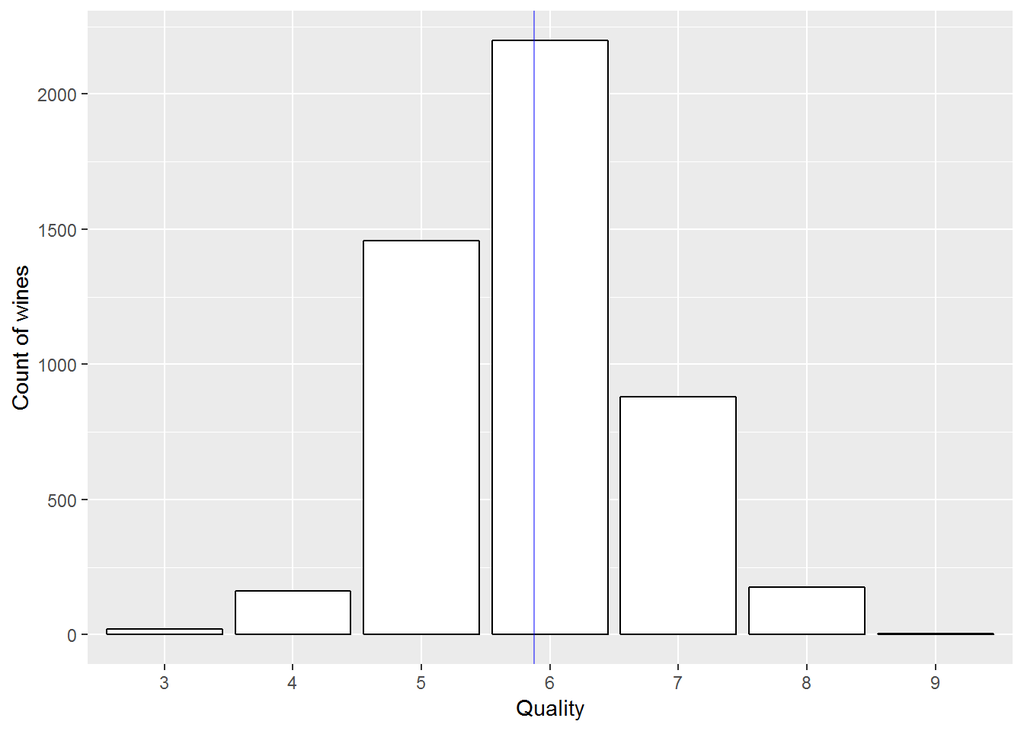

**Quality**  
Valores entre 3 e 9  
Os maiores picos são 5 e 6  
Distribuição normal com média aproximada de 5.9

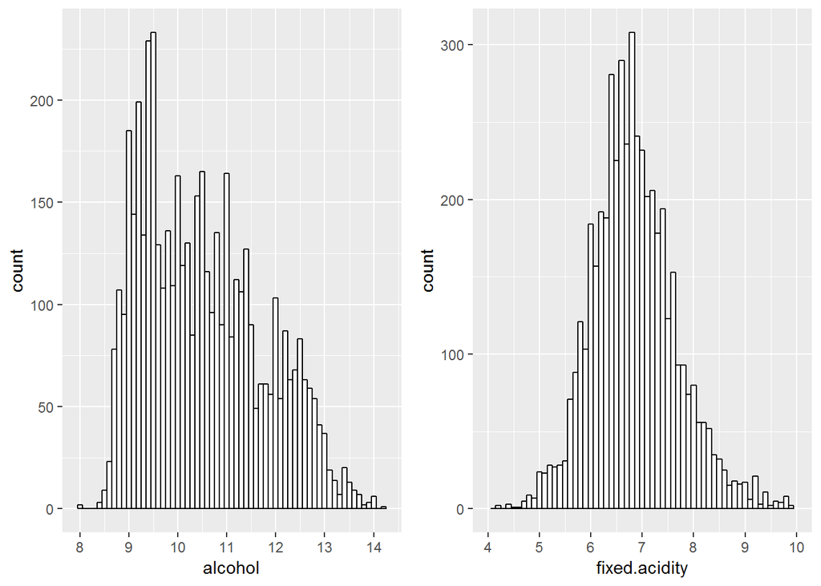

```
##    Min. 1st Qu.  Median    Mean 3rd Qu.    Max.
##    8.00    9.50   10.40   10.51   11.40   14.20
```

```
##    Min. 1st Qu.  Median    Mean 3rd Qu.    Max.
##   3.800   6.300   6.800   6.855   7.300  14.200
```

**Alcohol**  
Varia entre 8 e 14.2  
Os maiores picos estão entre 9 e 9.5  
Distribuição normal enviesada para direita  
**Fixed Acidity**  
Varia entre 3.8 e 14.2  
Distribuição normal com média de 6.855

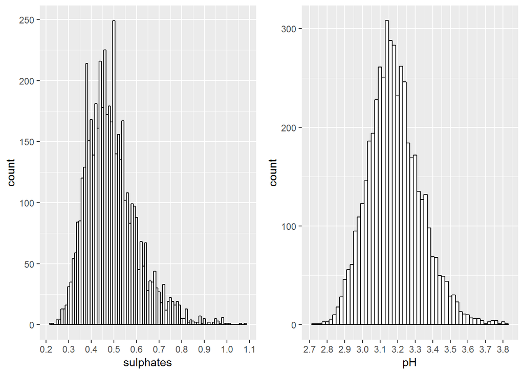

```
##    Min. 1st Qu.  Median    Mean 3rd Qu.    Max.
##  0.2200  0.4100  0.4700  0.4898  0.5500  1.0800
```

```
##    Min. 1st Qu.  Median    Mean 3rd Qu.    Max.
##   2.720   3.090   3.180   3.188   3.280   3.820
```

**Sulphates**  
Os valores estão por volta de 0.45  
Distribuição normal enviesada para direita  
**pH**  
Distribuição normal com média de 3.2

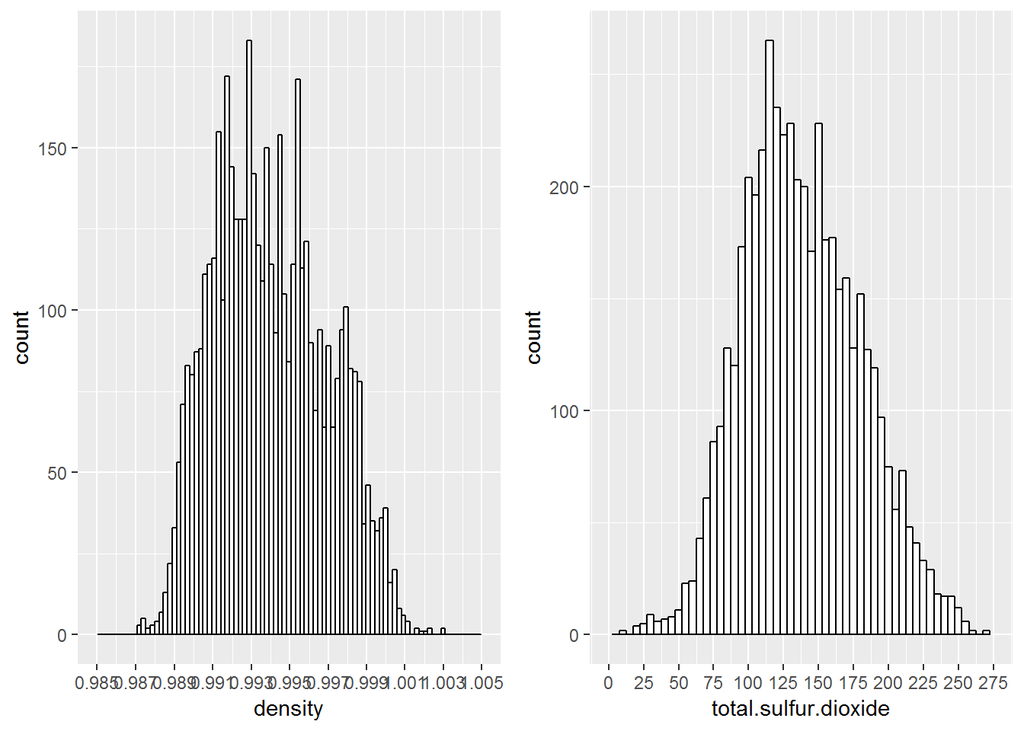

```
##    Min. 1st Qu.  Median    Mean 3rd Qu.    Max.
##  0.9871  0.9917  0.9937  0.9940  0.9961  1.0390
```

```
##    Min. 1st Qu.  Median    Mean 3rd Qu.    Max.
##     9.0   108.0   134.0   138.4   167.0   440.0
```

**Density**  
Outliers acima de 1.01  
Distribuição normal com média de 0.994  
**Total Sufur Dioxide**  
Outliers acima de 275  
Metade dos valores entre 108 e 167  
Distribuição normal com média de 138.4

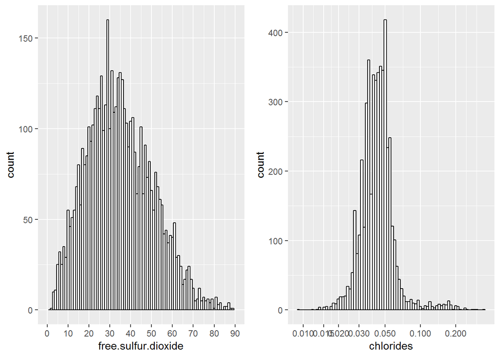

```
##    Min. 1st Qu.  Median    Mean 3rd Qu.    Max.
##    2.00   23.00   34.00   35.31   46.00  289.00
```

```
##    Min. 1st Qu.  Median    Mean 3rd Qu.    Max.
## 0.00900 0.03600 0.04300 0.04577 0.05000 0.34600
```

**Free Sulfur Dioxide**  
Outliers acima de 90  
Metade dos dados entre 23 e 46  
Distribuição normal com média perto de 35  
**Chlorides**  
Quase metade dos dados entre 0.036 e 0.05

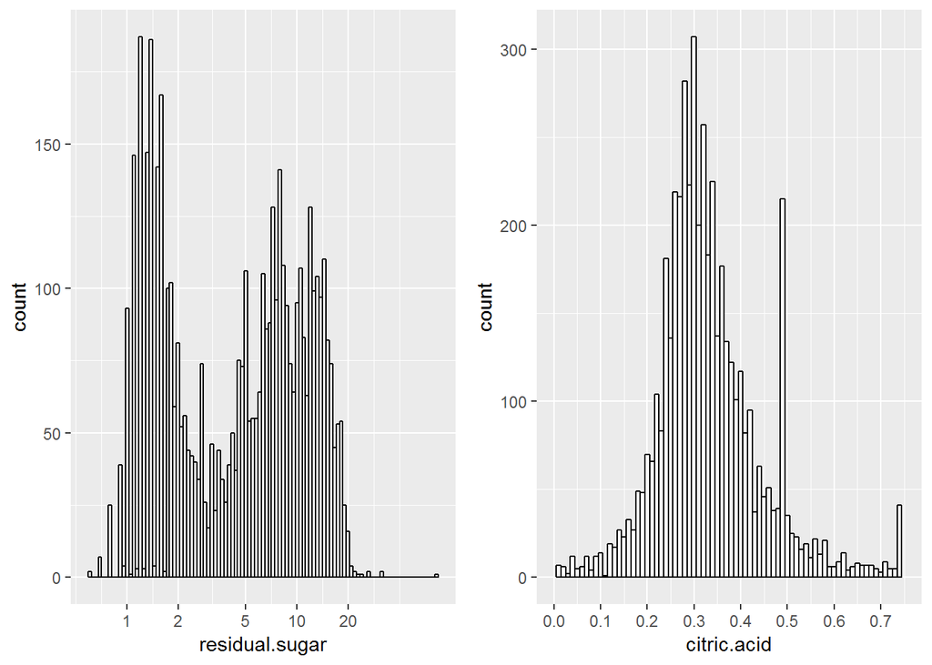

```
##    Min. 1st Qu.  Median    Mean 3rd Qu.    Max.
##   0.600   1.700   5.200   6.391   9.900  65.800
```

```
##    Min. 1st Qu.  Median    Mean 3rd Qu.    Max.
##  0.0000  0.2700  0.3200  0.3342  0.3900  1.6600
```

**Residual Sugar**  
Os dados foram transformados para entender melhor a distribuição do açúcar residual  
A distribuição transformada aparece bimodal com o preço chegando a cerca de 1,5 ou mais e novamente a 10 ou mais  
**Citric Acid**  
Outliers acima de 0.9  
Metade dos dados entre 0.27 e 0.39  
Distribuição normal com média perto de 0.33

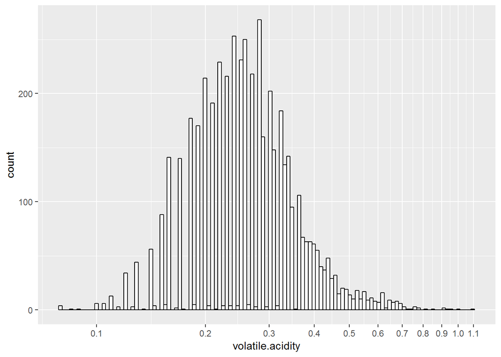

```
##    Min. 1st Qu.  Median    Mean 3rd Qu.    Max.
##  0.0800  0.2100  0.2600  0.2782  0.3200  1.1000
```

**Volatile Acidity**  
Os dados foram transformados para entender melhor a distribuição  
A distribuição transformada parece normal, com o acúmulo de aproximadamente 0,25

# Seção de Gráficos Bivariados

**Correlação das variáveis com a qualidade**

```
##                              [,1]
## fixed.acidity        -0.113662831
## volatile.acidity     -0.194722969
## citric.acid          -0.009209091
## residual.sugar       -0.097576829
## chlorides            -0.209934411
## free.sulfur.dioxide   0.008158067
## total.sulfur.dioxide -0.174737218
## density              -0.307123313
## pH                    0.099427246
## sulphates             0.053677877
## alcohol               0.435574715
## quality               1.000000000
```

Neste relatório iremos focar a correlação das variáveis com a variável-alvo (quality).  
Os maiores valores são:  
alcohol = 0.435574715  
density = -0.307123313  
chlorides = -0.209934411  
volatile.acidity = -0.194722969

**Alcohol**

```
##    Min. 1st Qu.  Median    Mean 3rd Qu.    Max.
##    8.00    9.50   10.40   10.51   11.40   14.20
```

```
##        3        4        5        6        7        8        9
## 10.34500 10.15245  9.80884 10.57537 11.36794 11.63600 12.18000
```

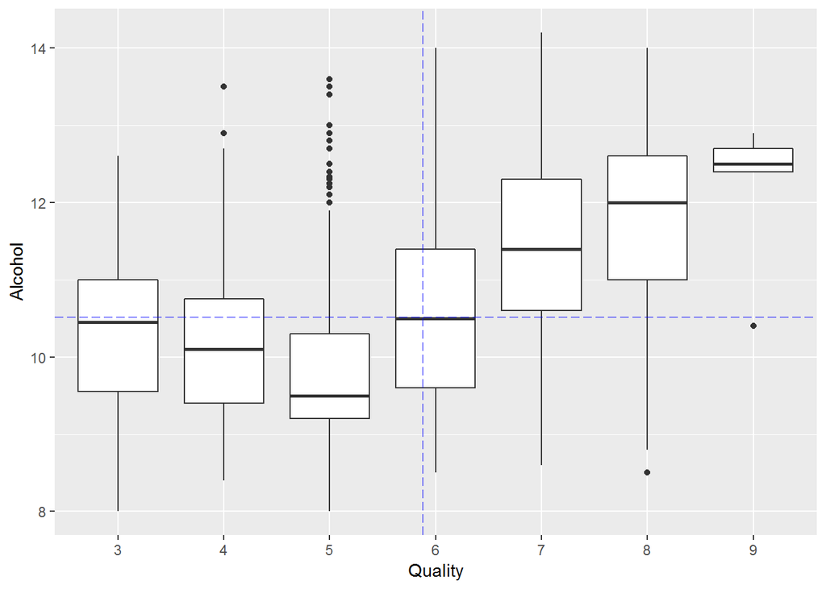

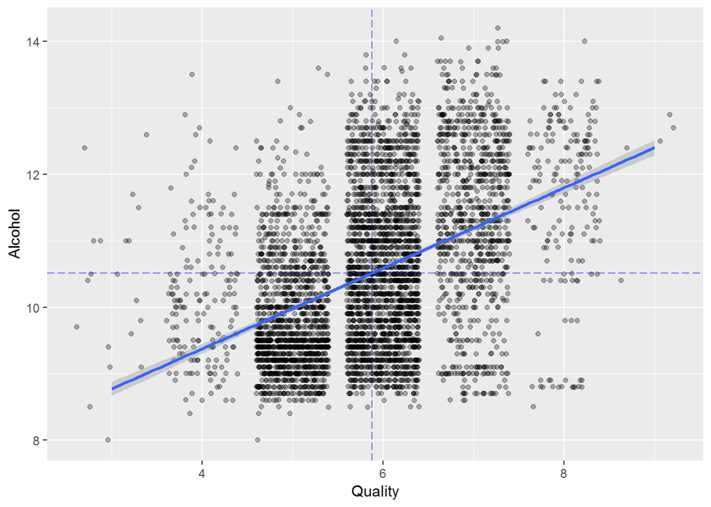

Os vinhos com qualidade acima da média tem mais alcool que a média geral (10.51).

**Density**

```
##    Min. 1st Qu.  Median    Mean 3rd Qu.    Max.
##  0.9871  0.9917  0.9937  0.9940  0.9961  1.0390
```

```
##         3         4         5         6         7         8         9
## 0.9948840 0.9942767 0.9952626 0.9939613 0.9924524 0.9922359 0.9914600
```

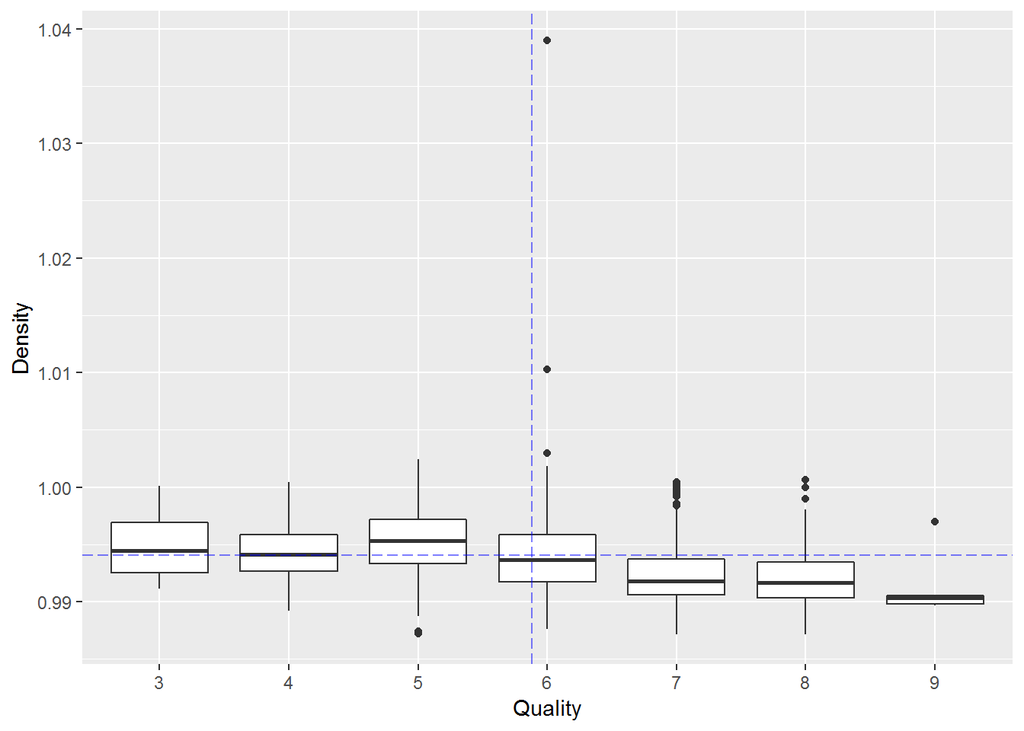

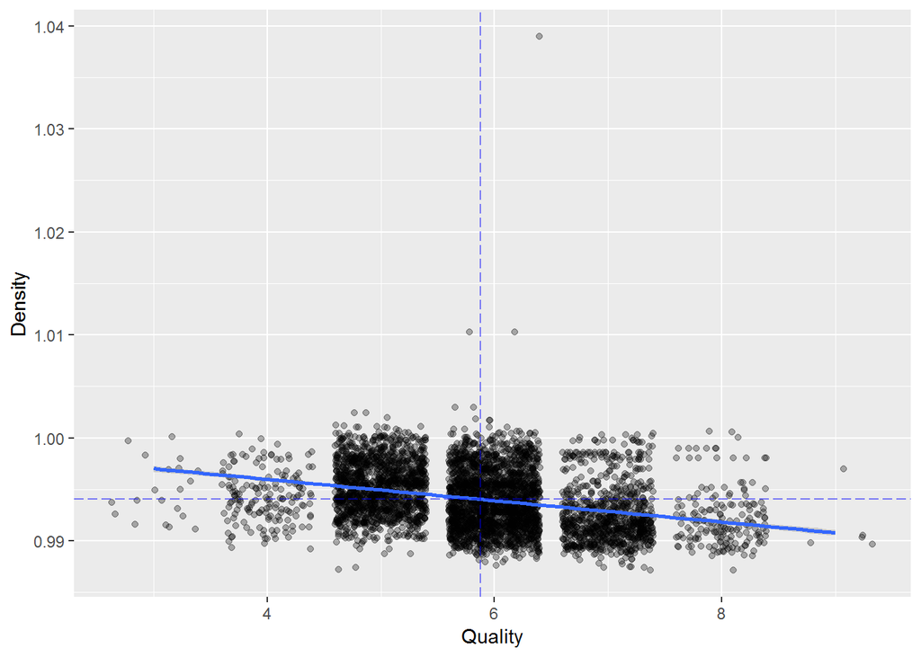

Os vinhos com qualidade acima da média tem menos densidade que a média geral (0.994).

**Chlorides**

```
##    Min. 1st Qu.  Median    Mean 3rd Qu.    Max.
## 0.00900 0.03600 0.04300 0.04577 0.05000 0.34600
```

```
##          3          4          5          6          7          8
## 0.05430000 0.05009816 0.05154633 0.04521747 0.03819091 0.03831429
##          9
## 0.02740000
```

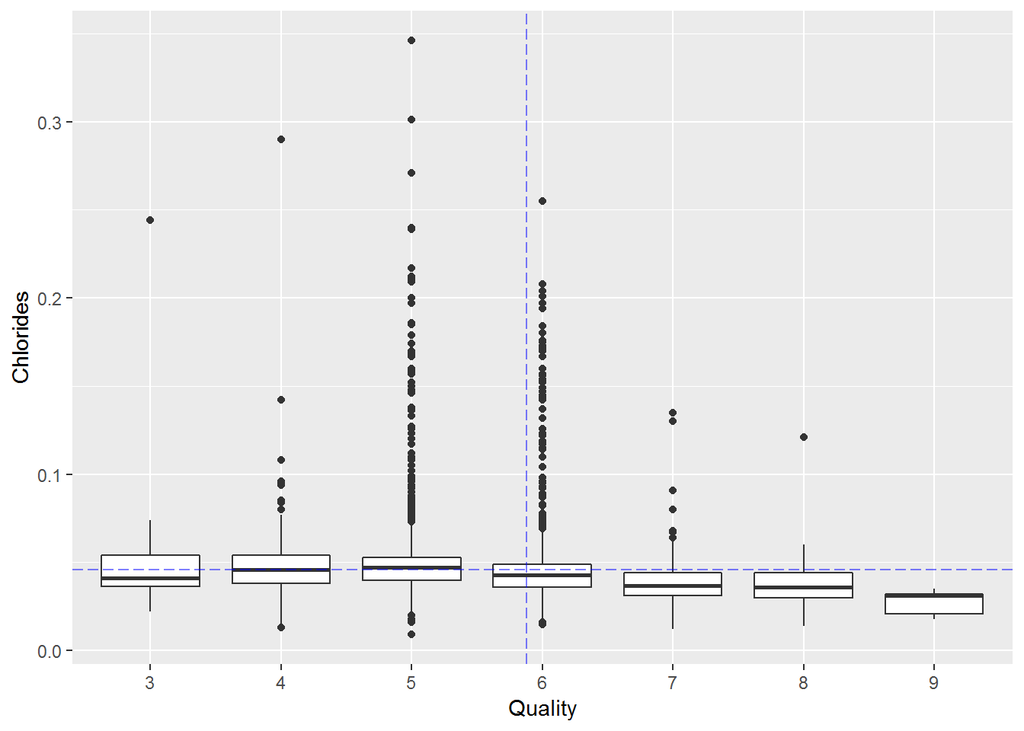

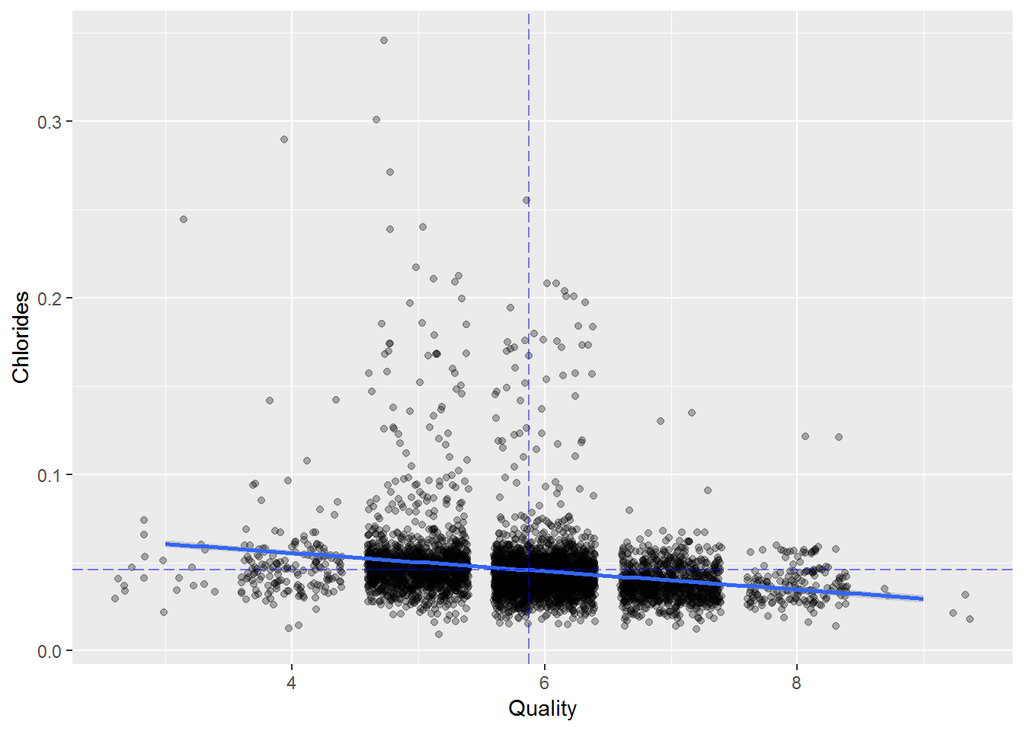

Os vinhos com qualidade acima da média tem menos chlorides que a média geral (0.04577).  
Essa variável possui um número considerável de outliers.

**Volatile Acidity**

```
##    Min. 1st Qu.  Median    Mean 3rd Qu.    Max.
##  0.0800  0.2100  0.2600  0.2782  0.3200  1.1000
```

```
##         3         4         5         6         7         8         9
## 0.3332500 0.3812270 0.3020110 0.2605641 0.2627670 0.2774000 0.2980000
```

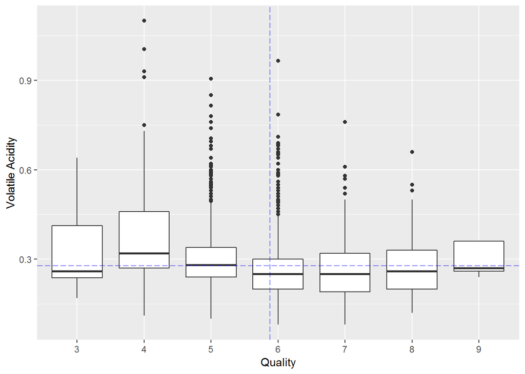

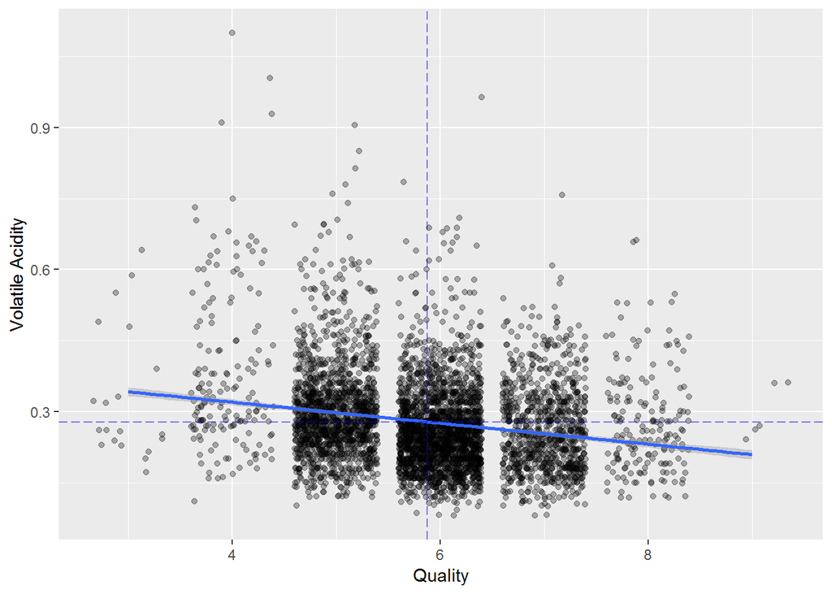

# Seção de Gráficos Multivariados

**Densidade x Alcool com Qualidade**

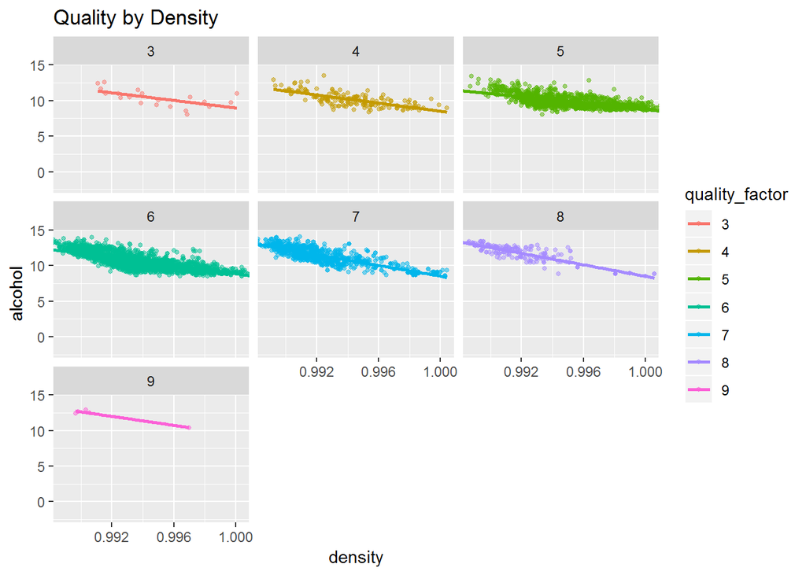

Notamos que em todos os níveis de qualidade à medida que a densidade aumenta, o percentual de alcool diminui.

**Chlorides x Volatile Acidity com Qualidade**

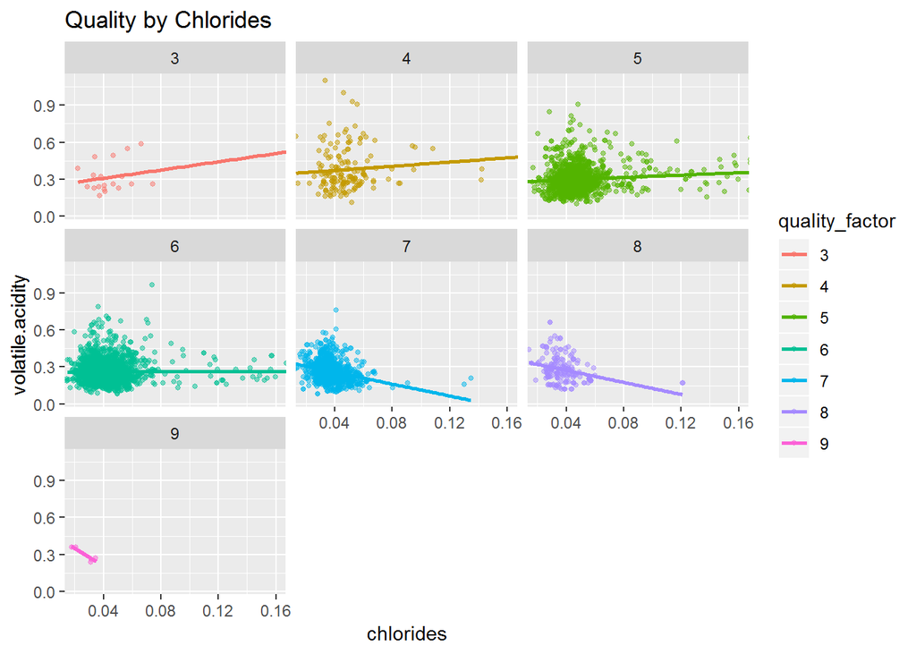

# Gráficos Finais e Sumário

### Primeiro Gráfico

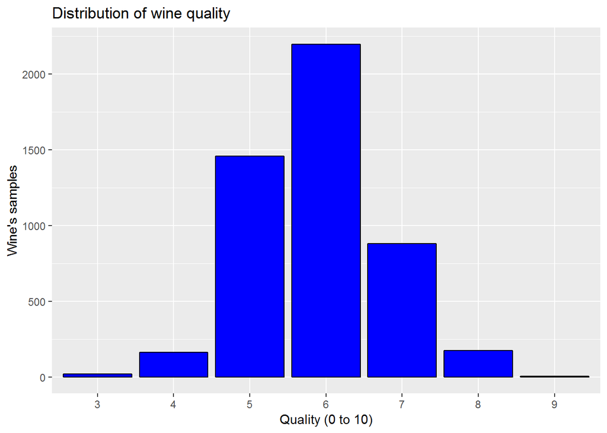

### Descrição do Primeiro Gráfico

Verificamos que a maioria dos vinhos brancos obteve nota 6, 5 e 7 (respectivamente).

### Segundo Gráfico

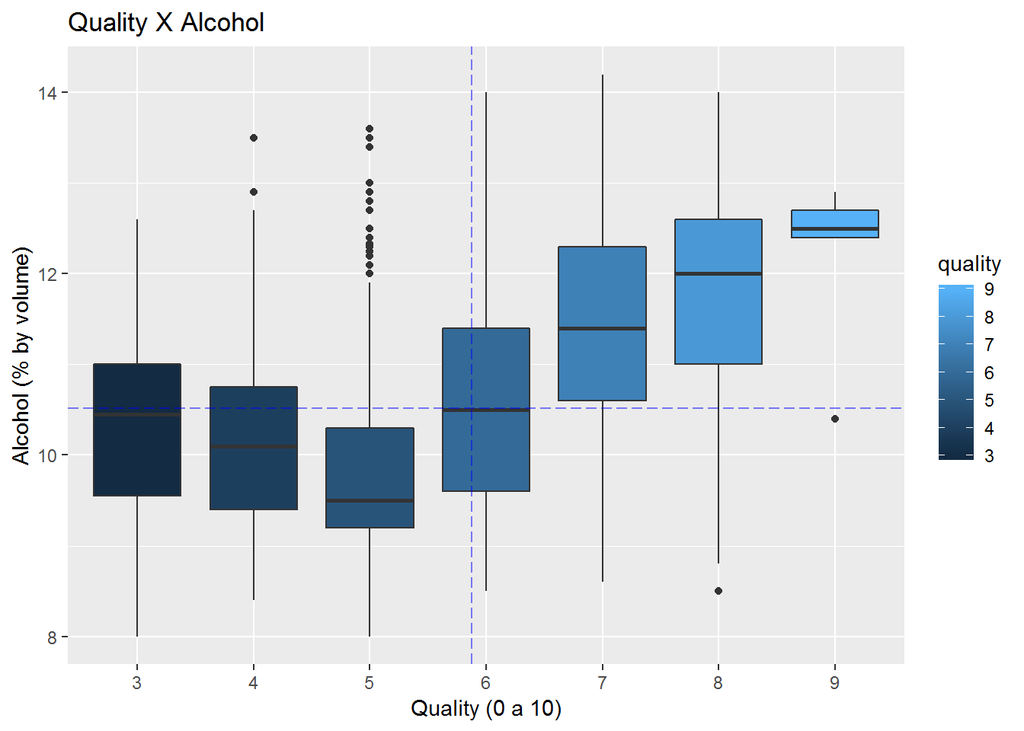

### Descrição do Segundo Gráfico

O boxplot nos mostra a relação entre alcool e qualidade e nos permite avaliar essa relação de forma mais precisa, mostrando que, à medida que a qualidade aumenta de 3 para 5, o nível médio de álcool na verdade diminui. No entanto, à medida que a qualidade aumenta acima de 5, o nível mediano de álcool aumenta constantemente de 9,5% para 12,5%.  
0% de álcool acima de certos limiares terá impacto negativo na qualidade do vinho.

### Terceiro Gráfico

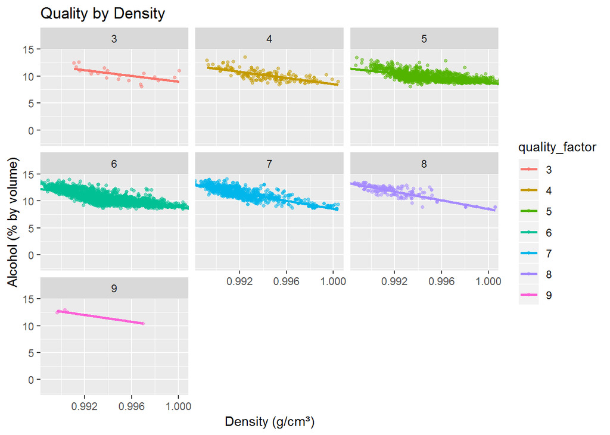

### Descrição do Terceiro Gráfico

Álcool e Densidade são as variáveis com maior correlação com a variável-alvo: qualidade.  
Notamos que o comportamento entre essas variáveis é a mesma em todos os níveis de qualidade.  
À medida que o valor da densidade aumenta, o valor do alcool diminui.

# Reflexão